# Renege_Modelling-Final

```python
# Step 1: Reading the dataset
import pandas as pd

# Reading the dataset in a CSV file named 'POFU_Dataset (1).csv'
df = pd.read_csv('POFU_Dataset (1).csv')

# Step 2: Describing the dataset

display(df.head())  # Displaying the first few rows of the dataset
```

|  | DOJ_Extended | Duration_to_agree_offer | Noticeperiod | Offered_band | percent_expected_hike_inCTC | Percent_offered_hike_inCTC | PercentdifferenceCTC | Joining_Bonus | relocate_actual | Gender | RexinYrs | MS | Age | Status_num | Notice_period_buy_out | Willing_to_work_in_shifts | Willing_to_relocate_to_any_city | Did_candidate_reloacte | Interview_type |
| --- | --- | --- | --- | --- | --- | --- | --- | --- | --- | --- | --- | --- | --- | --- | --- | --- | --- | --- | --- |
| 0 | 0 | 5 | 60 | 1 | 39 | 20 | 19 | 0 | 0 | 1 | 1 | 0 | 25 | 1 | 0 | 0 | 0 | 0 | 1 |
| 1 | 0 | 14 | 0 | 1 | 20 | 20 | 0 | 0 | 0 | 1 | 1 | 1 | 44 | 0 | 0 | 0 | 1 | 1 | 1 |
| 2 | 0 | 14 | 60 | 1 | 36 | 30 | 6 | 1 | 1 | 1 | 6 | 1 | 27 | 0 | 1 | 0 | 1 | 1 | 1 |
| 3 | 1 | 5 | 30 | 1 | 21 | 20 | 1 | 0 | 0 | 1 | 4 | 1 | 40 | 0 | 0 | 0 | 1 | 1 | 1 |
| 4 | 1 | 3 | 60 | 1 | 40 | 22 | 18 | 0 | 1 | 1 | 7 | 1 | 44 | 0 | 1 | 0 | 1 | 1 | 1 |

```python
print("Dataset Description:")
print(df.info())  # Overview of columns, data types, and non-null counts
print("\nSummary Statistics:")
print(df.describe())  # Summary statistics of numeric columns
```

```
Dataset Description:
<class 'pandas.core.frame.DataFrame'>
RangeIndex: 9095 entries, 0 to 9094
Data columns (total 19 columns):
 #   Column                           Non-Null Count  Dtype
---  ------                           --------------  -----
 0   DOJ_Extended                     9095 non-null   int64
 1   Duration_to_agree_offer          9095 non-null   int64
 2   Noticeperiod                     9095 non-null   int64
 3   Offered_band                     9095 non-null   int64
 4   percent_expected_hike_inCTC      9095 non-null   int64
 5   Percent_offered_hike_inCTC       9095 non-null   int64
 6   PercentdifferenceCTC             9095 non-null   int64
 7   Joining_Bonus                    9095 non-null   int64
 8   relocate_actual                  9095 non-null   int64
 9   Gender                           9095 non-null   int64
 10  RexinYrs                         9095 non-null   int64
 11  MS                               9095 non-null   int64
 12  Age                              9095 non-null   int64
 13  Status_num                       9095 non-null   int64
 14  Notice_period_buy_out            9095 non-null   int64
 15  Willing_to_work_in_shifts        9095 non-null   int64
 16  Willing_to_relocate_to_any_city  9095 non-null   int64
 17  Did_candidate_reloacte           9095 non-null   int64
 18  Interview_type                   9095 non-null   int64
dtypes: int64(19)
memory usage: 1.3 MB
None

Summary Statistics:
       DOJ_Extended  Duration_to_agree_offer  Noticeperiod  Offered_band  \
count   9095.000000              9095.000000   9095.000000   9095.000000
mean       0.465421                 7.931721     54.847719      1.387576
std        0.498830                 4.348425     20.411330      0.636891
min        0.000000                 1.000000      0.000000      0.000000
25%        0.000000                 4.000000     60.000000      1.000000
50%        0.000000                 8.000000     60.000000      1.000000
75%        1.000000                12.000000     60.000000      2.000000
max        1.000000                15.000000     90.000000      4.000000

```

[output cut: 34 more lines]

```
min                 0.000000                   0.000000
25%                 0.000000                   0.000000
50%                 0.000000                   0.000000
75%                 0.000000                   0.000000
max                 1.000000                   1.000000

       Willing_to_relocate_to_any_city  Did_candidate_reloacte  Interview_type
count                      9095.000000             9095.000000     9095.000000
mean                          0.813744                0.813744        0.805498
std                           0.389335                0.389335        0.395839
min                           0.000000                0.000000        0.000000
25%                           1.000000                1.000000        1.000000
50%                           1.000000                1.000000        1.000000
75%                           1.000000                1.000000        1.000000
max                           1.000000                1.000000        1.000000
```

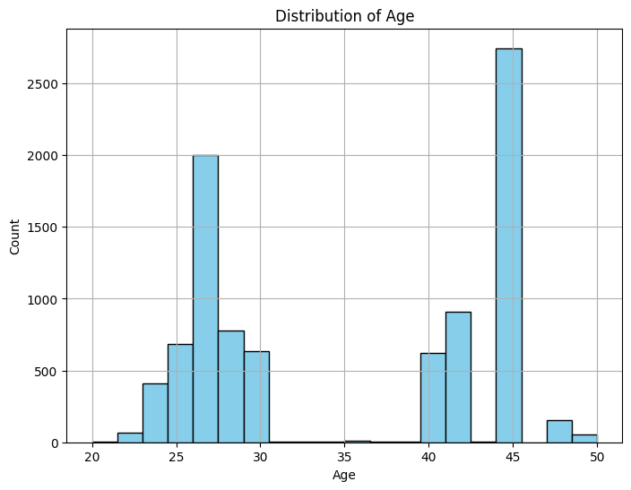

```python
import matplotlib.pyplot as plt

# Plotting the distribution of 'Age'
plt.figure(figsize=(8, 6))
plt.hist(df['Age'], bins=20, color='skyblue', edgecolor='black')
plt.xlabel('Age')
plt.ylabel('Count')
plt.title('Distribution of Age')
plt.grid(True)
plt.show()
```

```python
# Step 3: Data Preprocessing
# In this step, we will handle any missing values, encode categorical variables (if present),
# and perform any necessary feature engineering.

# Handling Missing Values (if any)
df.isnull().sum()#No nulls
# For example, if there are missing values, you can choose to impute them with the mean, median, or mode.
# df.fillna(df.mean(), inplace=True)

# Encoding Categorical Variables (if any),(No String Categories)
# If there are categorical variables, you can encode them using techniques like one-hot encoding or label encoding.
# For example, using one-hot encoding:
# df = pd.get_dummies(df, columns=['Gender', 'Interview_type'])
```

```
DOJ_Extended                       0
Duration_to_agree_offer            0
Noticeperiod                       0
Offered_band                       0
percent_expected_hike_inCTC        0
Percent_offered_hike_inCTC         0
PercentdifferenceCTC               0
Joining_Bonus                      0
relocate_actual                    0
Gender                             0
RexinYrs                           0
MS                                 0
Age                                0
Status_num                         0
Notice_period_buy_out              0
Willing_to_work_in_shifts          0
Willing_to_relocate_to_any_city    0
Did_candidate_reloacte             0
Interview_type                     0
dtype: int64
```

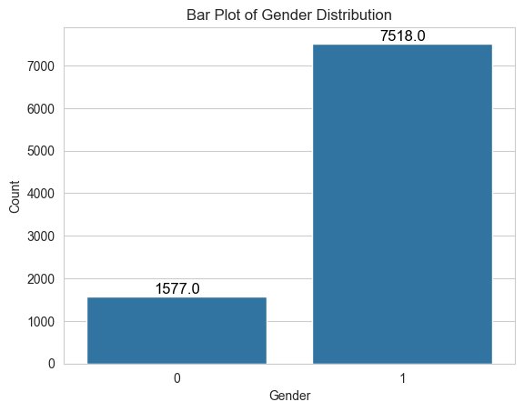

```python
import seaborn as sns
import matplotlib.pyplot as plt

# Assuming 'df' is your DataFrame containing the data
sns.set_style("whitegrid")  # Optional: Set a whitegrid background for the plot
ax = sns.countplot(x='Gender', data=df)
plt.xlabel('Gender')
plt.ylabel('Count')
plt.title('Bar Plot of Gender Distribution')

# Add labels to the bars
for p in ax.patches:
    ax.annotate(f'{p.get_height()}', (p.get_x() + p.get_width() / 2., p.get_height()),
                ha='center', va='bottom', fontsize=12, color='black')

plt.show()
```

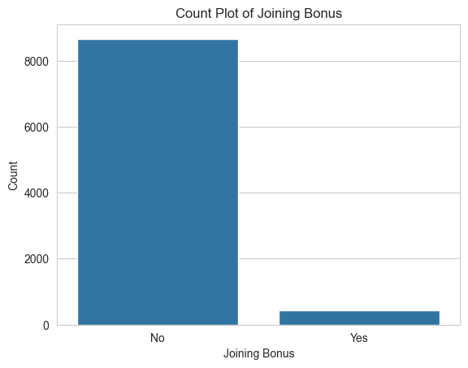

```python
import seaborn as sns
import matplotlib.pyplot as plt

# Assuming 'df' is your DataFrame containing the data
sns.countplot(x='Joining_Bonus', data=df)
plt.xlabel('Joining Bonus')
plt.ylabel('Count')
plt.title('Count Plot of Joining Bonus')
plt.xticks([0, 1], ['No', 'Yes'])  # Customizing x-axis ticks
plt.show()
```

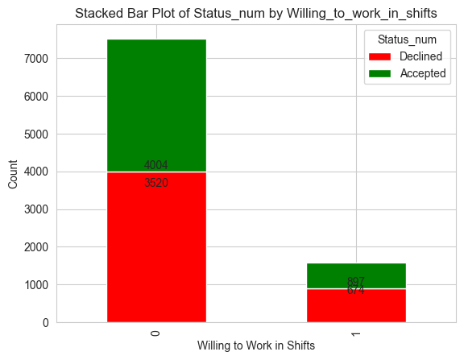

```python
import matplotlib.pyplot as plt

# Group the data by 'Willing_to_work_in_shifts' and 'Status_num', and get the counts
status_counts = df.groupby(['Willing_to_work_in_shifts', 'Status_num']).size().unstack()

# Create the stacked bar plot
ax = status_counts.plot(kind='bar', stacked=True, color=['red', 'green'])

# Add labels and title
plt.xlabel('Willing to Work in Shifts')
plt.ylabel('Count')
plt.title('Stacked Bar Plot of Status_num by Willing_to_work_in_shifts')
plt.legend(title='Status_num', loc='upper right', labels=['Declined', 'Accepted'])

# Add labels for each bar
for i in ax.patches:
    # Get the height of the bar
    height = i.get_height()
    # Add the count as a label at the top of the bar
    ax.text(i.get_x() + i.get_width() / 2, height, str(int(height)), ha='center', va='bottom')

plt.show()
```

[figure not shown]

```python
import matplotlib.pyplot as plt

# Get the counts of candidates who relocated and who did not
relocate_counts = df['Did_candidate_reloacte'].value_counts()

# Create a pie chart
plt.figure(figsize=(6, 6))
plt.pie(relocate_counts, labels=['Did Not Relocate', 'Relocated'], autopct='%1.1f%%', colors=['skyblue', 'lightgreen'], startangle=90)

# Add title
plt.title('Proportion of Candidates by Relocation Status')

plt.show()
```

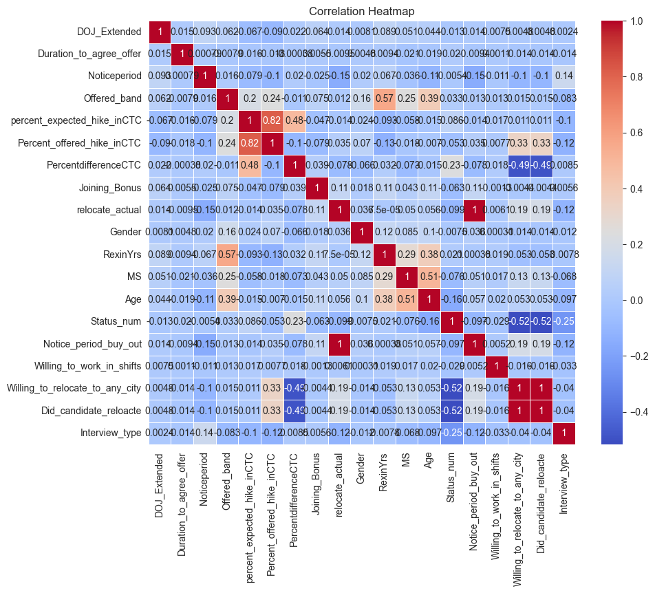

```python
import seaborn as sns
import matplotlib.pyplot as plt

# Calculate the correlation matrix
correlation_matrix = df.corr()

# Create a heatmap
plt.figure(figsize=(10, 8))
sns.heatmap(correlation_matrix, annot=True, cmap='coolwarm', linewidths=0.5)
plt.title('Correlation Heatmap')
plt.show()
```

```python
# Set the threshold for high correlation (can be adjusted as per your requirement)
threshold = 0.85

# Find the highly correlated features
highly_correlated_features = set()
num_features = len(correlation_matrix.columns)

for i in range(num_features):
    for j in range(i):
        if abs(correlation_matrix.iloc[i, j]) > threshold:
            # Get the names of the highly correlated features
            feature_i = correlation_matrix.columns[i]
            feature_j = correlation_matrix.columns[j]
            highly_correlated_features.add(feature_i)
            highly_correlated_features.add(feature_j)

# Convert the set of highly correlated features to a list
highly_correlated_features_list = list(highly_correlated_features)

# Display the list of highly correlated features
print("Highly Correlated Features:")
print(highly_correlated_features_list)
```

```
Highly Correlated Features:
['relocate_actual', 'Willing_to_relocate_to_any_city', 'Notice_period_buy_out', 'Did_candidate_reloacte']
```

```python
# Drop the less relevant feature
df.drop(columns=['Did_candidate_reloacte', 'relocate_actual'], inplace=True)
```

```python
# Feature Scaling (if required)
# Depending on the model chosen, you may need to scale the numeric features to a similar range.
# For example, using Min-Max scaling:
from sklearn.preprocessing import MinMaxScaler
scaler = MinMaxScaler()
df1 = pd.DataFrame(scaler.fit_transform(df), columns=df.columns)
df1.head()
```

|  | DOJ_Extended | Duration_to_agree_offer | Noticeperiod | Offered_band | percent_expected_hike_inCTC | Percent_offered_hike_inCTC | PercentdifferenceCTC | Joining_Bonus | Gender | RexinYrs | MS | Age | Status_num | Notice_period_buy_out | Willing_to_work_in_shifts | Willing_to_relocate_to_any_city | Interview_type |
| --- | --- | --- | --- | --- | --- | --- | --- | --- | --- | --- | --- | --- | --- | --- | --- | --- | --- |
| 0 | 0.0 | 0.285714 | 0.666667 | 0.25 | 0.316667 | 0.000000 | 0.395833 | 0.0 | 1.0 | 0.041667 | 0.0 | 0.166667 | 1.0 | 0.0 | 0.0 | 0.0 | 1.0 |
| 1 | 0.0 | 0.928571 | 0.000000 | 0.25 | 0.000000 | 0.000000 | 0.000000 | 0.0 | 1.0 | 0.041667 | 1.0 | 0.800000 | 0.0 | 0.0 | 0.0 | 1.0 | 1.0 |
| 2 | 0.0 | 0.928571 | 0.666667 | 0.25 | 0.266667 | 0.192308 | 0.125000 | 1.0 | 1.0 | 0.250000 | 1.0 | 0.233333 | 0.0 | 1.0 | 0.0 | 1.0 | 1.0 |
| 3 | 1.0 | 0.285714 | 0.333333 | 0.25 | 0.016667 | 0.000000 | 0.020833 | 0.0 | 1.0 | 0.166667 | 1.0 | 0.666667 | 0.0 | 0.0 | 0.0 | 1.0 | 1.0 |
| 4 | 1.0 | 0.142857 | 0.666667 | 0.25 | 0.333333 | 0.038462 | 0.375000 | 0.0 | 1.0 | 0.291667 | 1.0 | 0.800000 | 0.0 | 1.0 | 0.0 | 1.0 | 1.0 |

```python
# Removing Irrelevant Features (if any)
# If certain columns are irrelevant or redundant for the predictive model, they can be dropped.
# For example, if 'Offered_band' is not a relevant predictor, you can drop it.
# df.drop(columns=['Offered_band'], inplace=True)
```

```python
# Splitting Data into Features (X) and Target (y)
# 'Status_num' is the target variable and the rest are features
X = df1.drop(columns=['Status_num'])
y = df1['Status_num']

# Now your preprocessed data (X and y) is ready for further modeling and analysis.
```

### ANN

```python
import torch
import torch.nn as nn
import torch.optim as optim
import numpy as np
from sklearn.model_selection import train_test_split
from sklearn.metrics import confusion_matrix, accuracy_score, precision_score, recall_score, f1_score
```

```python
# Ensure X and y are NumPy arrays before splitting
X_annwo = X.to_numpy() if isinstance(X, pd.DataFrame) else X
y_annwo = y.to_numpy() if isinstance(y, pd.Series) else y  # y might be a Series
```

```python
# Splitting data into training and testing sets (80% train, 20% test)
X_train_annwo, X_test_annwo, y_train_annwo, y_test_annwo = train_test_split(X_annwo, y_annwo, test_size=0.2, random_state=42)
# Convert data to PyTorch tensors
X_train_annwo = torch.tensor(X_train_annwo, dtype=torch.float32)
X_test_annwo = torch.tensor(X_test_annwo, dtype=torch.float32)
y_train_annwo = torch.tensor(y_train_annwo, dtype=torch.float32).view(-1, 1)
y_test_annwo = torch.tensor(y_test_annwo, dtype=torch.float32).view(-1, 1)
```

```python
# Define the ANN model in PyTorch
class ANN(nn.Module):
    def __init__(self, input_size):
        super(ANN, self).__init__()
        self.model = nn.Sequential(
            nn.Linear(input_size, 16),
            nn.ReLU(),
            nn.Linear(16, 8),
            nn.ReLU(),
            nn.Linear(8, 1),
            nn.Sigmoid()  # Output activation for binary classification
        )

    def forward(self, x):
        return self.model(x)
```

```python
# Instantiate the model
model = ANN(X_train_annwo.shape[1])
```

```python
# Define loss function and optimizer
criterion = nn.BCELoss()  # Binary Cross Entropy Loss
optimizer = optim.Adam(model.parameters(), lr=0.001)
```

```python
# Training loop
epochs = 50
batch_size = 32
for epoch in range(epochs):
    model.train()

    for i in range(0, len(X_train_annwo), batch_size):
        X_batch = X_train_annwo[i:i+batch_size]
        y_batch = y_train_annwo[i:i+batch_size]

        optimizer.zero_grad()
        y_pred = model(X_batch)
        loss = criterion(y_pred, y_batch)
        loss.backward()
        optimizer.step()

    if (epoch + 1) % 10 == 0:
        print(f"Epoch {epoch+1}/{epochs}, Loss: {loss.item():.4f}")
```

[output not shown]

```python
# Model evaluation on training data
model.eval()
with torch.no_grad():
    y_train_pred_probs = model(X_train_annwo)
    y_train_pred = (y_train_pred_probs > 0.5).float()  # Apply thresholding
```

```python
# Convert predictions to NumPy for metrics
y_train_pred_np = y_train_pred.numpy()
y_train_np = y_train_annwo.numpy()
```

```python
# Compute metrics
conf_matrix_train = confusion_matrix(y_train_np, y_train_pred_np)
train_accuracy = accuracy_score(y_train_np, y_train_pred_np)
train_precision = precision_score(y_train_np, y_train_pred_np)
train_recall = recall_score(y_train_np, y_train_pred_np)
train_f1 = f1_score(y_train_np, y_train_pred_np)

# Print results
print("\nConfusion Matrix on Training Data:")
print(conf_matrix_train)
print("\nEvaluation Metrics on Training Data:")
print(f"Accuracy: {train_accuracy:.2f}")
print(f"Precision: {train_precision:.2f}")
print(f"Recall: {train_recall:.2f}")
print(f"F1-Score: {train_f1:.2f}")
```

```
Confusion Matrix on Training Data:
[[3769  161]
 [1185 2161]]

Evaluation Metrics on Training Data:
Accuracy: 0.82
Precision: 0.93
Recall: 0.65
F1-Score: 0.76
```

```python
#Evaluate the model on the testing data
model.eval()  # Set the model to evaluation mode

with torch.no_grad():  # Disable gradient computation for testing
    y_test_pred_probs = model(X_test_annwo)  # Get predicted probabilities
    y_test_pred = (y_test_pred_probs > 0.5).float()  # Apply thresholding at 0.5

# Convert predictions and actual values to NumPy arrays for metric calculation
y_test_pred_np = y_test_pred.numpy()
y_test_np = y_test_annwo.numpy()
```

```python
# Compute evaluation metrics
conf_matrix_test = confusion_matrix(y_test_np, y_test_pred_np)
test_accuracy = accuracy_score(y_test_np, y_test_pred_np)
test_precision = precision_score(y_test_np, y_test_pred_np)
test_recall = recall_score(y_test_np, y_test_pred_np)
test_f1 = f1_score(y_test_np, y_test_pred_np)

# Print results
print("\nConfusion Matrix on Test Data:")
print(conf_matrix_test)

print("\nEvaluation Metrics on Testing Data:")
print(f"Accuracy: {test_accuracy:.2f}")
print(f"Precision: {test_precision:.2f}")
print(f"Recall: {test_recall:.2f}")
print(f"F1-Score: {test_f1:.2f}")
```

```
Confusion Matrix on Test Data:
[[931  40]
 [315 533]]

Evaluation Metrics on Testing Data:
Accuracy: 0.80
Precision: 0.93
Recall: 0.63
F1-Score: 0.75
```

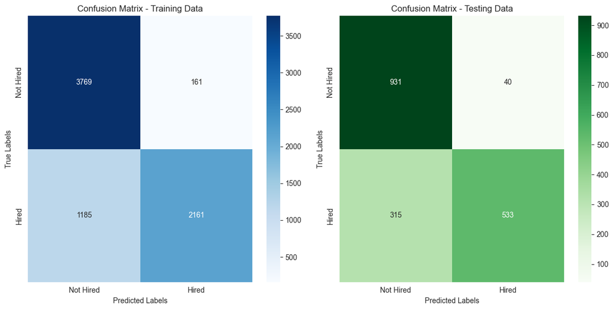

```python
import numpy as np
import seaborn as sns
import matplotlib.pyplot as plt
from sklearn.metrics import confusion_matrix

# Confusion matrix for training data and testing data

# Define the class labels
class_labels = ['Not Hired', 'Hired']

# Plot the heatmaps
plt.figure(figsize=(12, 6))
plt.subplot(1, 2, 1)
sns.heatmap(conf_matrix_train, annot=True, fmt='d', cmap='Blues', xticklabels=class_labels, yticklabels=class_labels)
plt.title('Confusion Matrix - Training Data')
plt.xlabel('Predicted Labels')
plt.ylabel('True Labels')

plt.subplot(1, 2, 2)
sns.heatmap(conf_matrix_test, annot=True, fmt='d', cmap='Greens', xticklabels=class_labels, yticklabels=class_labels)
plt.title('Confusion Matrix - Testing Data')
plt.xlabel('Predicted Labels')
plt.ylabel('True Labels')

plt.tight_layout()
plt.show()
```

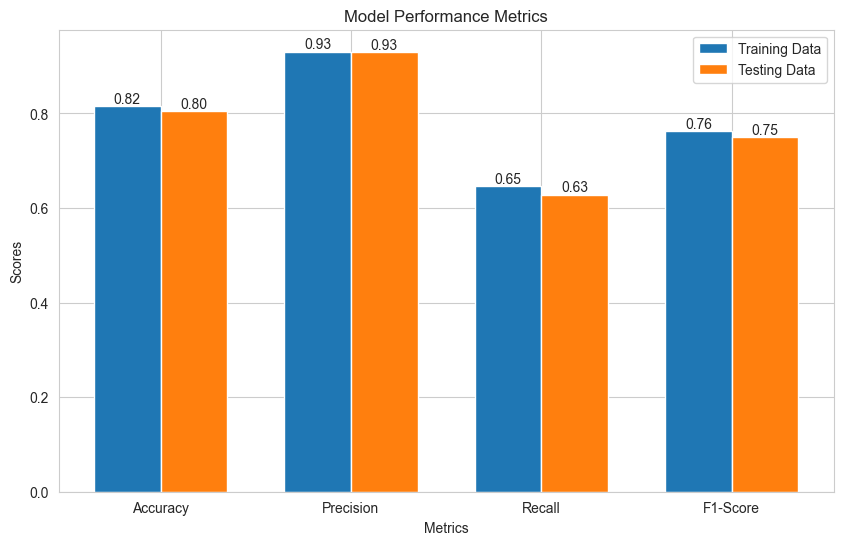

```python
import matplotlib.pyplot as plt



# List of metrics and corresponding values
metrics = ['Accuracy', 'Precision', 'Recall', 'F1-Score']
train_scores = [train_accuracy, train_precision, train_recall, train_f1]
test_scores = [test_accuracy, test_precision, test_recall, test_f1]

# Create a bar plot
plt.figure(figsize=(10, 6))
bar_width = 0.35
index = range(len(metrics))

plt.bar(index, train_scores, bar_width, label='Training Data')
plt.bar([i + bar_width for i in index], test_scores, bar_width, label='Testing Data')

# Add labels and title
plt.xlabel('Metrics')
plt.ylabel('Scores')
plt.title('Model Performance Metrics')
plt.xticks([i + bar_width/2 for i in index], metrics)
plt.legend()

# Add labels to the bars
for i, train_score in enumerate(train_scores):
    plt.text(i, train_score, f"{train_score:.2f}", ha='center', va='bottom')

for i, test_score in enumerate(test_scores):
    plt.text(i + bar_width, test_score, f"{test_score:.2f}", ha='center', va='bottom')

plt.show()
```

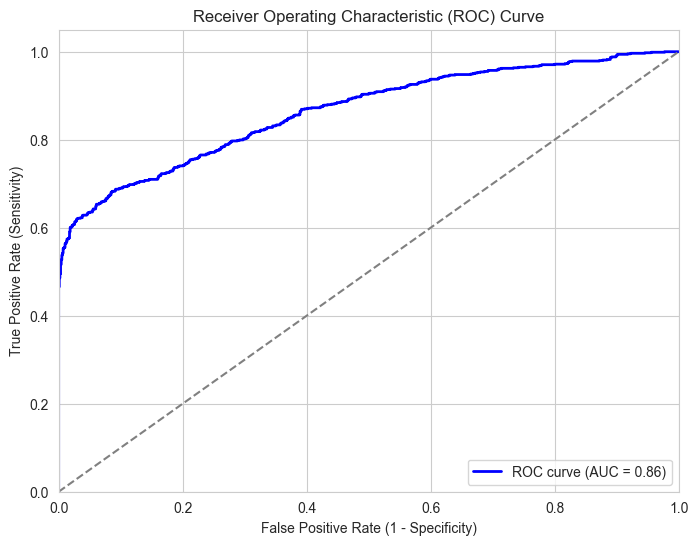

```python
import matplotlib.pyplot as plt
from sklearn.metrics import roc_curve, roc_auc_score


# Compute the false positive rate, true positive rate, and thresholds
fpr, tpr, thresholds = roc_curve(y_test, y_test_pred_probs)

# Calculate the area under the ROC curve (AUC)
roc_auc = roc_auc_score(y_test, y_test_pred_probs)

# Plot the ROC curve
plt.figure(figsize=(8, 6))
plt.plot(fpr, tpr, color='blue', lw=2, label=f'ROC curve (AUC = {roc_auc:.2f})')
plt.plot([0, 1], [0, 1], color='gray', linestyle='--')
plt.xlim([0.0, 1.0])
plt.ylim([0.0, 1.05])
plt.xlabel('False Positive Rate (1 - Specificity)')
plt.ylabel('True Positive Rate (Sensitivity)')
plt.title('Receiver Operating Characteristic (ROC) Curve')
plt.legend(loc='lower right')
plt.grid(True)
plt.show()
```

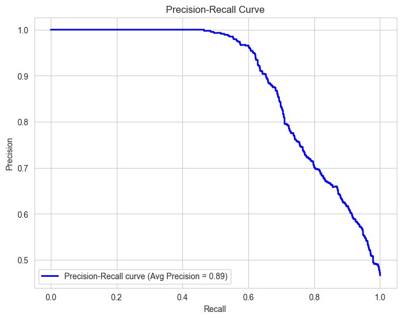

```python
import matplotlib.pyplot as plt
from sklearn.metrics import precision_recall_curve, average_precision_score


# Compute precision, recall, and thresholds
precision, recall, thresholds = precision_recall_curve(y_test, y_test_pred_probs)

# Calculate the average precision score
avg_precision = average_precision_score(y_test, y_test_pred_probs)

# Plot the Precision-Recall curve
plt.figure(figsize=(8, 6))
plt.plot(recall, precision, color='blue', lw=2, label=f'Precision-Recall curve (Avg Precision = {avg_precision:.2f})')
plt.xlabel('Recall')
plt.ylabel('Precision')
plt.title('Precision-Recall Curve')
plt.legend(loc='lower left')
plt.grid(True)
plt.show()
```

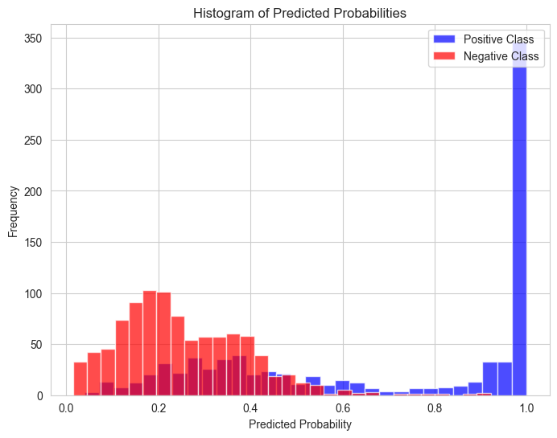

```python
import matplotlib.pyplot as plt



# Separate the predicted probabilities for positive and negative classes
positive_probs = y_test_pred_probs[y_test_annwo == 1]
negative_probs = y_test_pred_probs[y_test_annwo == 0]

# Plot histograms
plt.figure(figsize=(8, 6))
plt.hist(positive_probs, bins=30, alpha=0.7, color='blue', label='Positive Class')
plt.hist(negative_probs, bins=30, alpha=0.7, color='red', label='Negative Class')
plt.xlabel('Predicted Probability')
plt.ylabel('Frequency')
plt.title('Histogram of Predicted Probabilities')
plt.legend(loc='upper right')
plt.grid(True)
plt.show()
```

```python
from sklearn.preprocessing import MinMaxScaler

# Sample data for all features (including dummy features to match the model)
sample_data = {
    'DOJ_Extended': [5],
    'Duration_to_agree_offer': [60],
    'Noticeperiod': [1],
    'percent_expected_hike_inCTC': [39],
    'Percent_offered_hike_inCTC': [20],
    'PercentdifferenceCTC': [19],
    'Joining_Bonus': [0],
    'Gender': [1],
    'RexinYrs': [1],
    'MS': [0],
    'Age': [25],
    'Notice_period_buy_out': [1],
    'Willing_to_work_in_shifts': [0],
    'Willing_to_relocate_to_any_city': [0],
    'Interview_type': [0],
    'Offered_band': [1]  # Add a dummy value for 'Offered_band'
}

# Create a DataFrame from the sample data
sample_df = pd.DataFrame(sample_data)

# Standardize the sample data using the same scaler used during training
scaler = MinMaxScaler()
sample_df = pd.DataFrame(scaler.fit_transform(sample_df), columns=sample_df.columns)

# Convert sample data to a PyTorch tensor
sample_tensor = torch.tensor(sample_df.values, dtype=torch.float32)

# Set model to evaluation mode
model.eval()

# Make prediction
with torch.no_grad():
    y_pred_prob = model(sample_tensor)  # Get probability
    y_pred = (y_pred_prob > 0.5).float()  # Apply thresholding

# Display the prediction for 'Status_num'
print("Predicted 'Status_num' for the given record:")
print(int(y_pred[0].item()))  # Convert tensor to integer
```

```
Predicted 'Status_num' for the given record:
1
```

### Support Vector Classifier

```python
# Splitting data into training and testing sets (80% train, 20% test)
X_train, X_test, y_train, y_test = train_test_split(X, y, test_size=0.2, random_state=42)
```

```python
from sklearn.svm import SVC

# Step 1: Build the SVC model
model = SVC(kernel='linear', C=1.0, random_state=42)

# Step 2: Train the SVC model
model.fit(X_train, y_train)
```

```
SVC(kernel='linear', random_state=42)
```

```python
# Step 3: Evaluate the model on the training data
y_train_pred = model.predict(X_train)
conf_matrix_train = confusion_matrix(y_train, y_train_pred)
print("\nConfusion Matrix on train data:")
print(conf_matrix_train)
train_accuracy = accuracy_score(y_train, y_train_pred)
train_precision = precision_score(y_train, y_train_pred)
train_recall = recall_score(y_train, y_train_pred)
train_f1 = f1_score(y_train, y_train_pred)

print("Evaluation Metrics on Training Data:")
print(f"Accuracy: {train_accuracy:.2f}")
print(f"Precision: {train_precision:.2f}")
print(f"Recall: {train_recall:.2f}")
print(f"F1-Score: {train_f1:.2f}")
```

```
Confusion Matrix on train data:
[[3530  400]
 [1185 2161]]
Evaluation Metrics on Training Data:
Accuracy: 0.78
Precision: 0.84
Recall: 0.65
F1-Score: 0.73
```

```python
# Step 4: Evaluate the model on the testing data
y_test_pred = model.predict(X_test)
conf_matrix_test = confusion_matrix(y_test, y_test_pred)
print("\nConfusion Matrix on test data:")
print(conf_matrix_test)
test_accuracy = accuracy_score(y_test, y_test_pred)
test_precision = precision_score(y_test, y_test_pred)
test_recall = recall_score(y_test, y_test_pred)
test_f1 = f1_score(y_test, y_test_pred)

print("\nEvaluation Metrics on Testing Data:")
print(f"Accuracy: {test_accuracy:.2f}")
print(f"Precision: {test_precision:.2f}")
print(f"Recall: {test_recall:.2f}")
print(f"F1-Score: {test_f1:.2f}")
```

```
Confusion Matrix on test data:
[[871 100]
 [320 528]]

Evaluation Metrics on Testing Data:
Accuracy: 0.77
Precision: 0.84
Recall: 0.62
F1-Score: 0.72
```

### Decision Tree Classifier

```python
from sklearn.tree import DecisionTreeClassifier

# Step 1: Build the Decision Tree classifier
model = DecisionTreeClassifier(random_state=42)

# Step 2: Train the Decision Tree classifier
model.fit(X_train, y_train)
```

```
DecisionTreeClassifier(random_state=42)
```

```python
# Step 3: Evaluate the model on the training data
y_train_pred = model.predict(X_train)
conf_matrix_train = confusion_matrix(y_train, y_train_pred)
print("\nConfusion Matrix on train data:")
print(conf_matrix_train)
train_accuracy = accuracy_score(y_train, y_train_pred)
train_precision = precision_score(y_train, y_train_pred)
train_recall = recall_score(y_train, y_train_pred)
train_f1 = f1_score(y_train, y_train_pred)

print("Evaluation Metrics on Training Data:")
print(f"Accuracy: {train_accuracy:.2f}")
print(f"Precision: {train_precision:.2f}")
print(f"Recall: {train_recall:.2f}")
print(f"F1-Score: {train_f1:.2f}")
```

```
Confusion Matrix on train data:
[[3930    0]
 [  27 3319]]
Evaluation Metrics on Training Data:
Accuracy: 1.00
Precision: 1.00
Recall: 0.99
F1-Score: 1.00
```

```python
# Step 4: Evaluate the model on the testing data
y_test_pred = model.predict(X_test)
conf_matrix_test = confusion_matrix(y_test, y_test_pred)
print("\nConfusion Matrix on test data:")
print(conf_matrix_test)
test_accuracy = accuracy_score(y_test, y_test_pred)
test_precision = precision_score(y_test, y_test_pred)
test_recall = recall_score(y_test, y_test_pred)
test_f1 = f1_score(y_test, y_test_pred)

print("\nEvaluation Metrics on Testing Data:")
print(f"Accuracy: {test_accuracy:.2f}")
print(f"Precision: {test_precision:.2f}")
print(f"Recall: {test_recall:.2f}")
print(f"F1-Score: {test_f1:.2f}")
```

```
Confusion Matrix on test data:
[[748 223]
 [223 625]]

Evaluation Metrics on Testing Data:
Accuracy: 0.75
Precision: 0.74
Recall: 0.74
F1-Score: 0.74
```

### random forest Classifier

```python
from sklearn.ensemble import RandomForestClassifier

# Step 1: Build the Random Forest classifier
model = RandomForestClassifier(n_estimators=100, random_state=42)

# Step 2: Train the Random Forest classifier
model.fit(X_train, y_train)
```

```
RandomForestClassifier(random_state=42)
```

```python
# Step 3: Evaluate the model on the training data
y_train_pred = model.predict(X_train)
conf_matrix_train = confusion_matrix(y_train, y_train_pred)
print("\nConfusion Matrix on train data:")
print(conf_matrix_train)
train_accuracy = accuracy_score(y_train, y_train_pred)
train_precision = precision_score(y_train, y_train_pred)
train_recall = recall_score(y_train, y_train_pred)
train_f1 = f1_score(y_train, y_train_pred)

print("Evaluation Metrics on Training Data:")
print(f"Accuracy: {train_accuracy:.2f}")
print(f"Precision: {train_precision:.2f}")
print(f"Recall: {train_recall:.2f}")
print(f"F1-Score: {train_f1:.2f}")
```

```
Confusion Matrix on train data:
[[3926    4]
 [  23 3323]]
Evaluation Metrics on Training Data:
Accuracy: 1.00
Precision: 1.00
Recall: 0.99
F1-Score: 1.00
```

```python
# Step 4: Evaluate the model on the testing data
y_test_pred = model.predict(X_test)
conf_matrix_test = confusion_matrix(y_test, y_test_pred)
print("\nConfusion Matrix on test data:")
print(conf_matrix_test)
test_accuracy = accuracy_score(y_test, y_test_pred)
test_precision = precision_score(y_test, y_test_pred)
test_recall = recall_score(y_test, y_test_pred)
test_f1 = f1_score(y_test, y_test_pred)

print("\nEvaluation Metrics on Testing Data:")
print(f"Accuracy: {test_accuracy:.2f}")
print(f"Precision: {test_precision:.2f}")
print(f"Recall: {test_recall:.2f}")
print(f"F1-Score: {test_f1:.2f}")
```

```
Confusion Matrix on test data:
[[873  98]
 [249 599]]

Evaluation Metrics on Testing Data:
Accuracy: 0.81
Precision: 0.86
Recall: 0.71
F1-Score: 0.78
```

### Navie Bayes Classifier

```python
from sklearn.naive_bayes import GaussianNB

# Step 1: Build the Naive Bayes classifier
model = GaussianNB()

# Step 2: Train the Naive Bayes classifier
model.fit(X_train, y_train)
```

```
GaussianNB()
```

```python
# Step 3: Evaluate the model on the training data
y_train_pred = model.predict(X_train)
conf_matrix_train = confusion_matrix(y_train, y_train_pred)
print("\nConfusion Matrix on train data:")
print(conf_matrix_train)
train_accuracy = accuracy_score(y_train, y_train_pred)
train_precision = precision_score(y_train, y_train_pred)
train_recall = recall_score(y_train, y_train_pred)
train_f1 = f1_score(y_train, y_train_pred)

print("Evaluation Metrics on Training Data:")
print(f"Accuracy: {train_accuracy:.2f}")
print(f"Precision: {train_precision:.2f}")
print(f"Recall: {train_recall:.2f}")
print(f"F1-Score: {train_f1:.2f}")
```

```
Confusion Matrix on train data:
[[3930    0]
 [1984 1362]]
Evaluation Metrics on Training Data:
Accuracy: 0.73
Precision: 1.00
Recall: 0.41
F1-Score: 0.58
```

```python
# Step 4: Evaluate the model on the testing data
y_test_pred = model.predict(X_test)
conf_matrix_test = confusion_matrix(y_test, y_test_pred)
print("\nConfusion Matrix on test data:")
print(conf_matrix_test)
test_accuracy = accuracy_score(y_test, y_test_pred)
test_precision = precision_score(y_test, y_test_pred)
test_recall = recall_score(y_test, y_test_pred)
test_f1 = f1_score(y_test, y_test_pred)

print("\nEvaluation Metrics on Testing Data:")
print(f"Accuracy: {test_accuracy:.2f}")
print(f"Precision: {test_precision:.2f}")
print(f"Recall: {test_recall:.2f}")
print(f"F1-Score: {test_f1:.2f}")
```

```
Confusion Matrix on test data:
[[971   0]
 [516 332]]

Evaluation Metrics on Testing Data:
Accuracy: 0.72
Precision: 1.00
Recall: 0.39
F1-Score: 0.56
```

### Gradient Boosting Classifier

```python
from sklearn.ensemble import GradientBoostingClassifier

# Step 1: Build the Gradient Boosting classifier
model = GradientBoostingClassifier()

# Step 2: Train the Gradient Boosting classifier
model.fit(X_train, y_train)
```

```
GradientBoostingClassifier()
```

```python
# Step 3: Evaluate the model on the training data
y_train_pred = model.predict(X_train)
conf_matrix_train = confusion_matrix(y_train, y_train_pred)
print("\nConfusion Matrix on train data:")
print(conf_matrix_train)
train_accuracy = accuracy_score(y_train, y_train_pred)
train_precision = precision_score(y_train, y_train_pred)
train_recall = recall_score(y_train, y_train_pred)
train_f1 = f1_score(y_train, y_train_pred)

print("Evaluation Metrics on Training Data:")
print(f"Accuracy: {train_accuracy:.2f}")
print(f"Precision: {train_precision:.2f}")
print(f"Recall: {train_recall:.2f}")
print(f"F1-Score: {train_f1:.2f}")
```

```
Confusion Matrix on train data:
[[3828  102]
 [1104 2242]]
Evaluation Metrics on Training Data:
Accuracy: 0.83
Precision: 0.96
Recall: 0.67
F1-Score: 0.79
```

```python
# Step 4: Evaluate the model on the testing data
y_test_pred = model.predict(X_test)
conf_matrix_test = confusion_matrix(y_test, y_test_pred)
print("\nConfusion Matrix on test data:")
print(conf_matrix_test)
test_accuracy = accuracy_score(y_test, y_test_pred)
test_precision = precision_score(y_test, y_test_pred)
test_recall = recall_score(y_test, y_test_pred)
test_f1 = f1_score(y_test, y_test_pred)

print("\nEvaluation Metrics on Testing Data:")
print(f"Accuracy: {test_accuracy:.2f}")
print(f"Precision: {test_precision:.2f}")
print(f"Recall: {test_recall:.2f}")
print(f"F1-Score: {test_f1:.2f}")
```

```
Confusion Matrix on test data:
[[949  22]
 [280 568]]

Evaluation Metrics on Testing Data:
Accuracy: 0.83
Precision: 0.96
Recall: 0.67
F1-Score: 0.79
```

### Logistic Regression

```python
from sklearn.linear_model import LogisticRegression

# Step 1: Build the Logistic Regression classifier
model = LogisticRegression()

# Step 2: Train the Logistic Regression classifier
model.fit(X_train, y_train)
```

```
LogisticRegression()
```

```python
# Step 3: Evaluate the model on the training data
y_train_pred = model.predict(X_train)
conf_matrix_train = confusion_matrix(y_train, y_train_pred)
print("\nConfusion Matrix on train data:")
print(conf_matrix_train)
train_accuracy = accuracy_score(y_train, y_train_pred)
train_precision = precision_score(y_train, y_train_pred)
train_recall = recall_score(y_train, y_train_pred)
train_f1 = f1_score(y_train, y_train_pred)

print("Evaluation Metrics on Training Data:")
print(f"Accuracy: {train_accuracy:.2f}")
print(f"Precision: {train_precision:.2f}")
print(f"Recall: {train_recall:.2f}")
print(f"F1-Score: {train_f1:.2f}")
```

```
Confusion Matrix on train data:
[[3624  306]
 [1174 2172]]
Evaluation Metrics on Training Data:
Accuracy: 0.80
Precision: 0.88
Recall: 0.65
F1-Score: 0.75
```

```python
# Step 4: Evaluate the model on the testing data
y_test_pred = model.predict(X_test)
conf_matrix_test = confusion_matrix(y_test, y_test_pred)
print("\nConfusion Matrix on test data:")
print(conf_matrix_test)
test_accuracy = accuracy_score(y_test, y_test_pred)
test_precision = precision_score(y_test, y_test_pred)
test_recall = recall_score(y_test, y_test_pred)
test_f1 = f1_score(y_test, y_test_pred)

print("\nEvaluation Metrics on Testing Data:")
print(f"Accuracy: {test_accuracy:.2f}")
print(f"Precision: {test_precision:.2f}")
print(f"Recall: {test_recall:.2f}")
print(f"F1-Score: {test_f1:.2f}")
```

```
Confusion Matrix on test data:
[[893  78]
 [314 534]]

Evaluation Metrics on Testing Data:
Accuracy: 0.78
Precision: 0.87
Recall: 0.63
F1-Score: 0.73
```

### Interaction Effects

Interaction effects refer to the combined effect of two or more variables on the target variable in a predictive model. In the context of classification models, interaction effects occur when the impact of one feature on the target variable depends on the values of another or multiple features.

In a classification model, such as logistic regression or support vector machine, interaction effects can be essential for capturing complex relationships between features and the target variable. Including interaction effects allows the model to account for cases where the effect of one feature on the target variable is different depending on the value of another feature. By considering these interactions, the model becomes more flexible and can capture non-linear relationships between features and the target variable.

Including interaction effects in classification models can be done in several ways:

Polynomial Features: By introducing polynomial features (e.g., squaring a feature, multiplying two features), the model can capture non-linear interactions between features.

Feature Engineering: Creating new features that represent combinations of existing features based on domain knowledge can help the model capture specific interactions.

Interaction Terms: In linear models like logistic regression, adding interaction terms between features allows the model to explicitly account for interactions.

Tree-based Models: Decision tree-based models like Random Forest and Gradient Boosting inherently capture interaction effects by recursively splitting data based on feature interactions.

The use of interaction effects in classification models helps improve model performance by considering more complex relationships between features and the target variable. However, it's essential to be cautious of overfitting, as including too many interaction terms can lead to a model that performs well on the training data but generalizes poorly to new, unseen data. Therefore, careful feature selection and regularization techniques are often employed to control for model complexity.

### Model Building with Interaction effects

```python
from sklearn.preprocessing import PolynomialFeatures
```

#### adding interaction effects to X_train

```python
# Transform the features into polynomial terms
poly = PolynomialFeatures(degree=2, include_bias=False)  # Adjust the degree as needed
X_train_poly = poly.fit_transform(X_train)
```

```python
# Create interaction terms
interaction_terms = []
for i in range(X_train_poly.shape[1]):
    for j in range(i+1, X_train_poly.shape[1]):
        interaction_term = X_train_poly[:, i] * X_train_poly[:, j]
        interaction_terms.append(interaction_term)
```

```python
# Concatenate the original features and interaction terms
X_train_poly = np.column_stack((X_train_poly, *interaction_terms))
```

#### adding interaction effects to X_test

```python
# Transform the features into polynomial terms
poly = PolynomialFeatures(degree=2, include_bias=False)  # Adjust the degree as needed
X_test_poly = poly.fit_transform(X_test)
```

```python
# Create interaction terms
interaction_terms1 = []
for i in range(X_test_poly.shape[1]):
    for j in range(i+1, X_test_poly.shape[1]):
        interaction_term1 = X_test_poly[:, i] * X_test_poly[:, j]
        interaction_terms1.append(interaction_term1)
```

```python
# Concatenate the original features and interaction terms
X_test_poly = np.column_stack((X_test_poly, *interaction_terms1))
```

#### Logistic Regression with Interaction Effects

```python
from sklearn.linear_model import LogisticRegression
```

```python
# Training the logistic regression model with polynomial features
model = LogisticRegression(max_iter=500)
model.fit(X_train_poly, y_train)
```

```
LogisticRegression(max_iter=500)
```

```python
# Making predictions on the training and testing data
y_train_pred = model.predict(X_train_poly)


# Confusion matrix and evaluation metrics for train data
conf_matrix_train = confusion_matrix(y_train, y_train_pred)
train_accuracy = accuracy_score(y_train, y_train_pred)
train_precision = precision_score(y_train, y_train_pred)
train_recall = recall_score(y_train, y_train_pred)
train_f1 = f1_score(y_train, y_train_pred)



# Printing the results
print("Confusion Matrix on train data:")
print(conf_matrix_train)
print("\nEvaluation Metrics on Training Data:")
print(f"Accuracy: {train_accuracy:.2f}")
print(f"Precision: {train_precision:.2f}")
print(f"Recall: {train_recall:.2f}")
print(f"F1-Score: {train_f1:.2f}")
```

```
Confusion Matrix on train data:
[[3750  180]
 [1049 2297]]

Evaluation Metrics on Training Data:
Accuracy: 0.83
Precision: 0.93
Recall: 0.69
F1-Score: 0.79
```

```python
y_test_pred = model.predict(X_test_poly)
# Confusion matrix and evaluation metrics for test data
conf_matrix_test = confusion_matrix(y_test, y_test_pred)
test_accuracy = accuracy_score(y_test, y_test_pred)
test_precision = precision_score(y_test, y_test_pred)
test_recall = recall_score(y_test, y_test_pred)
test_f1 = f1_score(y_test, y_test_pred)

print("\nConfusion Matrix on test data:")
print(conf_matrix_test)
print("\nEvaluation Metrics on Testing Data:")
print(f"Accuracy: {test_accuracy:.2f}")
print(f"Precision: {test_precision:.2f}")
print(f"Recall: {test_recall:.2f}")
print(f"F1-Score: {test_f1:.2f}")
```

```
Confusion Matrix on test data:
[[906  65]
 [288 560]]

Evaluation Metrics on Testing Data:
Accuracy: 0.81
Precision: 0.90
Recall: 0.66
F1-Score: 0.76
```

#### Gradient Boosting Classifier with Interaction Effects

```python
from sklearn.ensemble import GradientBoostingClassifier

# Step 1: Build the Gradient Boosting classifier
model = GradientBoostingClassifier()

# Step 2: Train the Gradient Boosting classifier
model.fit(X_train_poly, y_train)
```

```
GradientBoostingClassifier()
```

```python
# Making predictions on the training and testing data
y_train_pred = model.predict(X_train_poly)


# Confusion matrix and evaluation metrics for train data
conf_matrix_train = confusion_matrix(y_train, y_train_pred)
train_accuracy = accuracy_score(y_train, y_train_pred)
train_precision = precision_score(y_train, y_train_pred)
train_recall = recall_score(y_train, y_train_pred)
train_f1 = f1_score(y_train, y_train_pred)



# Printing the results
print("Confusion Matrix on train data:")
print(conf_matrix_train)
print("\nEvaluation Metrics on Training Data:")
print(f"Accuracy: {train_accuracy:.2f}")
print(f"Precision: {train_precision:.2f}")
print(f"Recall: {train_recall:.2f}")
print(f"F1-Score: {train_f1:.2f}")
```

```
Confusion Matrix on train data:
[[3826  104]
 [1012 2334]]

Evaluation Metrics on Training Data:
Accuracy: 0.85
Precision: 0.96
Recall: 0.70
F1-Score: 0.81
```

```python
y_test_pred = model.predict(X_test_poly)
# Confusion matrix and evaluation metrics for test data
conf_matrix_test = confusion_matrix(y_test, y_test_pred)
test_accuracy = accuracy_score(y_test, y_test_pred)
test_precision = precision_score(y_test, y_test_pred)
test_recall = recall_score(y_test, y_test_pred)
test_f1 = f1_score(y_test, y_test_pred)

print("\nConfusion Matrix on test data:")
print(conf_matrix_test)
print("\nEvaluation Metrics on Testing Data:")
print(f"Accuracy: {test_accuracy:.2f}")
print(f"Precision: {test_precision:.2f}")
print(f"Recall: {test_recall:.2f}")
print(f"F1-Score: {test_f1:.2f}")
```

```
Confusion Matrix on test data:
[[936  35]
 [278 570]]

Evaluation Metrics on Testing Data:
Accuracy: 0.83
Precision: 0.94
Recall: 0.67
F1-Score: 0.78
```

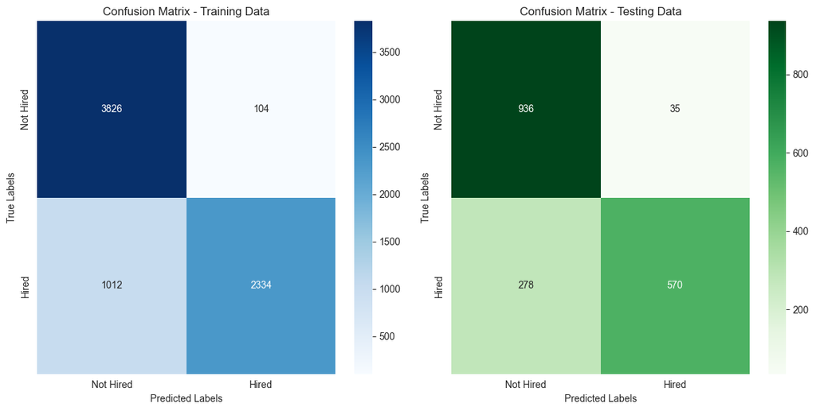

```python
import numpy as np
import seaborn as sns
import matplotlib.pyplot as plt
from sklearn.metrics import confusion_matrix

# Confusion matrix for training data and testing data

# Define the class labels
class_labels = ['Not Hired', 'Hired']

# Plot the heatmaps
plt.figure(figsize=(12, 6))
plt.subplot(1, 2, 1)
sns.heatmap(conf_matrix_train, annot=True, fmt='d', cmap='Blues', xticklabels=class_labels, yticklabels=class_labels)
plt.title('Confusion Matrix - Training Data')
plt.xlabel('Predicted Labels')
plt.ylabel('True Labels')

plt.subplot(1, 2, 2)
sns.heatmap(conf_matrix_test, annot=True, fmt='d', cmap='Greens', xticklabels=class_labels, yticklabels=class_labels)
plt.title('Confusion Matrix - Testing Data')
plt.xlabel('Predicted Labels')
plt.ylabel('True Labels')

plt.tight_layout()
plt.show()
```

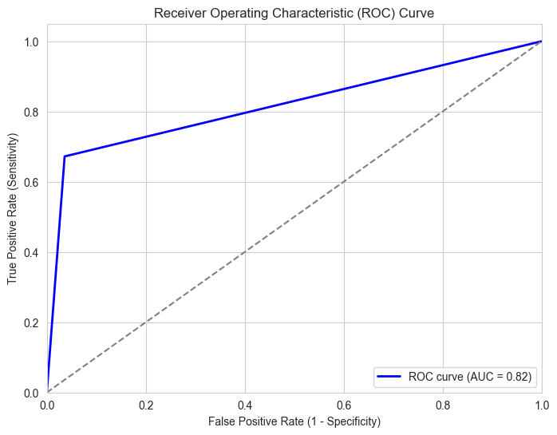

```python
import matplotlib.pyplot as plt
from sklearn.metrics import roc_curve, roc_auc_score


# Compute the false positive rate, true positive rate, and thresholds
fpr, tpr, thresholds = roc_curve(y_test, y_test_pred)

# Calculate the area under the ROC curve (AUC)
roc_auc = roc_auc_score(y_test, y_test_pred)

# Plot the ROC curve
plt.figure(figsize=(8, 6))
plt.plot(fpr, tpr, color='blue', lw=2, label=f'ROC curve (AUC = {roc_auc:.2f})')
plt.plot([0, 1], [0, 1], color='gray', linestyle='--')
plt.xlim([0.0, 1.0])
plt.ylim([0.0, 1.05])
plt.xlabel('False Positive Rate (1 - Specificity)')
plt.ylabel('True Positive Rate (Sensitivity)')
plt.title('Receiver Operating Characteristic (ROC) Curve')
plt.legend(loc='lower right')
plt.grid(True)
plt.show()
```

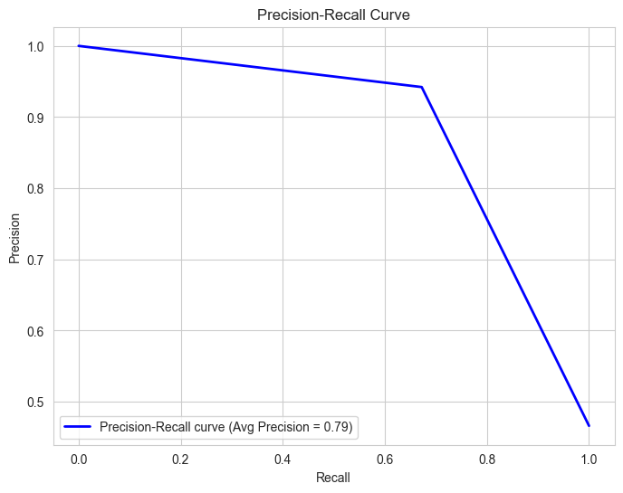

```python
import matplotlib.pyplot as plt
from sklearn.metrics import precision_recall_curve, average_precision_score


# Compute precision, recall, and thresholds
precision, recall, thresholds = precision_recall_curve(y_test, y_test_pred)

# Calculate the average precision score
avg_precision = average_precision_score(y_test, y_test_pred)

# Plot the Precision-Recall curve
plt.figure(figsize=(8, 6))
plt.plot(recall, precision, color='blue', lw=2, label=f'Precision-Recall curve (Avg Precision = {avg_precision:.2f})')
plt.xlabel('Recall')
plt.ylabel('Precision')
plt.title('Precision-Recall Curve')
plt.legend(loc='lower left')
plt.grid(True)
plt.show()
```

#### Gausiian Naive Bayes Classifier with interaction effects

```python
from sklearn.naive_bayes import GaussianNB

# Step 1: Build the Naive Bayes classifier
model = GaussianNB()

# Step 2: Train the Naive Bayes classifier
model.fit(X_train_poly, y_train)
```

```
GaussianNB()
```

```python
# Making predictions on the training and testing data
y_train_pred = model.predict(X_train_poly)


# Confusion matrix and evaluation metrics for train data
conf_matrix_train = confusion_matrix(y_train, y_train_pred)
train_accuracy = accuracy_score(y_train, y_train_pred)
train_precision = precision_score(y_train, y_train_pred)
train_recall = recall_score(y_train, y_train_pred)
train_f1 = f1_score(y_train, y_train_pred)



# Printing the results
print("Confusion Matrix on train data:")
print(conf_matrix_train)
print("\nEvaluation Metrics on Training Data:")
print(f"Accuracy: {train_accuracy:.2f}")
print(f"Precision: {train_precision:.2f}")
print(f"Recall: {train_recall:.2f}")
print(f"F1-Score: {train_f1:.2f}")
```

```
Confusion Matrix on train data:
[[1296 2634]
 [ 349 2997]]

Evaluation Metrics on Training Data:
Accuracy: 0.59
Precision: 0.53
Recall: 0.90
F1-Score: 0.67
```

```python
y_test_pred = model.predict(X_test_poly)
# Confusion matrix and evaluation metrics for test data
conf_matrix_test = confusion_matrix(y_test, y_test_pred)
test_accuracy = accuracy_score(y_test, y_test_pred)
test_precision = precision_score(y_test, y_test_pred)
test_recall = recall_score(y_test, y_test_pred)
test_f1 = f1_score(y_test, y_test_pred)

print("\nConfusion Matrix on test data:")
print(conf_matrix_test)
print("\nEvaluation Metrics on Testing Data:")
print(f"Accuracy: {test_accuracy:.2f}")
print(f"Precision: {test_precision:.2f}")
print(f"Recall: {test_recall:.2f}")
print(f"F1-Score: {test_f1:.2f}")
```

```
Confusion Matrix on test data:
[[318 653]
 [ 92 756]]

Evaluation Metrics on Testing Data:
Accuracy: 0.59
Precision: 0.54
Recall: 0.89
F1-Score: 0.67
```

#### RandomForestClassifier with Interaction Effects

```python
from sklearn.ensemble import RandomForestClassifier

# Step 1: Build the Random Forest classifier
model = RandomForestClassifier(n_estimators=100, random_state=42)

# Step 2: Train the Random Forest classifier
model.fit(X_train_poly, y_train)
```

```
RandomForestClassifier(random_state=42)
```

```python
# Making predictions on the training and testing data
y_train_pred = model.predict(X_train_poly)


# Confusion matrix and evaluation metrics for train data
conf_matrix_train = confusion_matrix(y_train, y_train_pred)
train_accuracy = accuracy_score(y_train, y_train_pred)
train_precision = precision_score(y_train, y_train_pred)
train_recall = recall_score(y_train, y_train_pred)
train_f1 = f1_score(y_train, y_train_pred)



# Printing the results
print("Confusion Matrix on train data:")
print(conf_matrix_train)
print("\nEvaluation Metrics on Training Data:")
print(f"Accuracy: {train_accuracy:.2f}")
print(f"Precision: {train_precision:.2f}")
print(f"Recall: {train_recall:.2f}")
print(f"F1-Score: {train_f1:.2f}")
```

```
Confusion Matrix on train data:
[[3923    7]
 [  20 3326]]

Evaluation Metrics on Training Data:
Accuracy: 1.00
Precision: 1.00
Recall: 0.99
F1-Score: 1.00
```

```python
y_test_pred = model.predict(X_test_poly)
# Confusion matrix and evaluation metrics for test data
conf_matrix_test = confusion_matrix(y_test, y_test_pred)
test_accuracy = accuracy_score(y_test, y_test_pred)
test_precision = precision_score(y_test, y_test_pred)
test_recall = recall_score(y_test, y_test_pred)
test_f1 = f1_score(y_test, y_test_pred)

print("\nConfusion Matrix on test data:")
print(conf_matrix_test)
print("\nEvaluation Metrics on Testing Data:")
print(f"Accuracy: {test_accuracy:.2f}")
print(f"Precision: {test_precision:.2f}")
print(f"Recall: {test_recall:.2f}")
print(f"F1-Score: {test_f1:.2f}")
```

```
Confusion Matrix on test data:
[[874  97]
 [251 597]]

Evaluation Metrics on Testing Data:
Accuracy: 0.81
Precision: 0.86
Recall: 0.70
F1-Score: 0.77
```

#### Decision Tree Classifier with interaction Efffets

```python
from sklearn.tree import DecisionTreeClassifier

# Step 1: Build the Decision Tree classifier
model = DecisionTreeClassifier(random_state=42)

# Step 2: Train the Decision Tree classifier
model.fit(X_train_poly, y_train)
```

```
DecisionTreeClassifier(random_state=42)
```

```python
# Making predictions on the training and testing data
y_train_pred = model.predict(X_train_poly)


# Confusion matrix and evaluation metrics for train data
conf_matrix_train = confusion_matrix(y_train, y_train_pred)
train_accuracy = accuracy_score(y_train, y_train_pred)
train_precision = precision_score(y_train, y_train_pred)
train_recall = recall_score(y_train, y_train_pred)
train_f1 = f1_score(y_train, y_train_pred)



# Printing the results
print("Confusion Matrix on train data:")
print(conf_matrix_train)
print("\nEvaluation Metrics on Training Data:")
print(f"Accuracy: {train_accuracy:.2f}")
print(f"Precision: {train_precision:.2f}")
print(f"Recall: {train_recall:.2f}")
print(f"F1-Score: {train_f1:.2f}")
```

```
Confusion Matrix on train data:
[[3930    0]
 [  27 3319]]

Evaluation Metrics on Training Data:
Accuracy: 1.00
Precision: 1.00
Recall: 0.99
F1-Score: 1.00
```

```python
y_test_pred = model.predict(X_test_poly)
# Confusion matrix and evaluation metrics for test data
conf_matrix_test = confusion_matrix(y_test, y_test_pred)
test_accuracy = accuracy_score(y_test, y_test_pred)
test_precision = precision_score(y_test, y_test_pred)
test_recall = recall_score(y_test, y_test_pred)
test_f1 = f1_score(y_test, y_test_pred)

print("\nConfusion Matrix on test data:")
print(conf_matrix_test)
print("\nEvaluation Metrics on Testing Data:")
print(f"Accuracy: {test_accuracy:.2f}")
print(f"Precision: {test_precision:.2f}")
print(f"Recall: {test_recall:.2f}")
print(f"F1-Score: {test_f1:.2f}")
```

```
Confusion Matrix on test data:
[[743 228]
 [224 624]]

Evaluation Metrics on Testing Data:
Accuracy: 0.75
Precision: 0.73
Recall: 0.74
F1-Score: 0.73
```

#### Support Vector Classifier with Interaction Effects

```python
from sklearn.svm import SVC

# Step 1: Build the SVC model
model = SVC(kernel='linear', C=1.0, random_state=42)

# Step 2: Train the SVC model
model.fit(X_train_poly, y_train)
```

```
SVC(kernel='linear', random_state=42)
```

```python
# Making predictions on the training and testing data
y_train_pred = model.predict(X_train_poly)


# Confusion matrix and evaluation metrics for train data
conf_matrix_train = confusion_matrix(y_train, y_train_pred)
train_accuracy = accuracy_score(y_train, y_train_pred)
train_precision = precision_score(y_train, y_train_pred)
train_recall = recall_score(y_train, y_train_pred)
train_f1 = f1_score(y_train, y_train_pred)



# Printing the results
print("Confusion Matrix on train data:")
print(conf_matrix_train)
print("\nEvaluation Metrics on Training Data:")
print(f"Accuracy: {train_accuracy:.2f}")
print(f"Precision: {train_precision:.2f}")
print(f"Recall: {train_recall:.2f}")
print(f"F1-Score: {train_f1:.2f}")
```

```
Confusion Matrix on train data:
[[3796  134]
 [1088 2258]]

Evaluation Metrics on Training Data:
Accuracy: 0.83
Precision: 0.94
Recall: 0.67
F1-Score: 0.79
```

```python
y_test_pred = model.predict(X_test_poly)
# Confusion matrix and evaluation metrics for test data
conf_matrix_test = confusion_matrix(y_test, y_test_pred)
test_accuracy = accuracy_score(y_test, y_test_pred)
test_precision = precision_score(y_test, y_test_pred)
test_recall = recall_score(y_test, y_test_pred)
test_f1 = f1_score(y_test, y_test_pred)

print("\nConfusion Matrix on test data:")
print(conf_matrix_test)
print("\nEvaluation Metrics on Testing Data:")
print(f"Accuracy: {test_accuracy:.2f}")
print(f"Precision: {test_precision:.2f}")
print(f"Recall: {test_recall:.2f}")
print(f"F1-Score: {test_f1:.2f}")
```

```
Confusion Matrix on test data:
[[915  56]
 [293 555]]

Evaluation Metrics on Testing Data:
Accuracy: 0.81
Precision: 0.91
Recall: 0.65
F1-Score: 0.76
```

### ANN with Interaction Effects

```python
# Convert data to PyTorch tensors
X_train_annw = torch.tensor(X_train_poly, dtype=torch.float32)
X_test_annw = torch.tensor(X_test_poly, dtype=torch.float32)
y_train_annw = torch.tensor(y_train_annwo, dtype=torch.float32).view(-1, 1)
y_test_annw = torch.tensor(y_test_annwo, dtype=torch.float32).view(-1, 1)
```

```python
# Define the ANN model
class ANN(nn.Module):
    def __init__(self, input_size):
        super(ANN, self).__init__()
        self.model = nn.Sequential(
            nn.Linear(input_size, 16),
            nn.ReLU(),
            nn.Linear(16, 8),
            nn.ReLU(),
            nn.Linear(8, 1),
            nn.Sigmoid()  # Sigmoid activation for binary classification
        )

    def forward(self, x):
        return self.model(x)
```

```python
# Initialize model
model = ANN(X_train_annw.shape[1])

# Define loss function and optimizer
criterion = nn.BCELoss()  # Binary Cross Entropy Loss
optimizer = optim.Adam(model.parameters(), lr=0.001)
```

```python
# Training the model
epochs = 50
batch_size = 32
for epoch in range(epochs):
    model.train()  # Set to training mode
    for i in range(0, len(X_train_annw), batch_size):
        X_batch = X_train_annw[i:i+batch_size]
        y_batch = y_train_annw[i:i+batch_size]

        optimizer.zero_grad()
        y_pred = model(X_batch)
        loss = criterion(y_pred, y_batch)
        loss.backward()
        optimizer.step()

    if (epoch + 1) % 10 == 0:
        print(f"Epoch {epoch+1}/{epochs}, Loss: {loss.item():.4f}")
```

[output not shown]

```python
# Evaluate the model on training data
model.eval()
with torch.no_grad():
    y_train_pred_probs = model(X_train_annw)
    y_train_pred = (y_train_pred_probs > 0.5).float()
```

```python
# Convert predictions to NumPy for metric calculation
y_train_pred_np = y_train_pred.numpy()
y_train_np = y_train_annw.numpy()
```

```python
# Compute training metrics
conf_matrix_train = confusion_matrix(y_train_np, y_train_pred_np)
train_accuracy = accuracy_score(y_train_np, y_train_pred_np)
train_precision = precision_score(y_train_np, y_train_pred_np)
train_recall = recall_score(y_train_np, y_train_pred_np)
train_f1 = f1_score(y_train_np, y_train_pred_np)

print("\nConfusion Matrix on Training Data:")
print(conf_matrix_train)
print("\nEvaluation Metrics on Training Data:")
print(f"Accuracy: {train_accuracy:.2f}")
print(f"Precision: {train_precision:.2f}")
print(f"Recall: {train_recall:.2f}")
print(f"F1-Score: {train_f1:.2f}")
```

```
Confusion Matrix on Training Data:
[[3844   86]
 [1109 2237]]

Evaluation Metrics on Training Data:
Accuracy: 0.84
Precision: 0.96
Recall: 0.67
F1-Score: 0.79
```

```python
# Evaluate the model on testing data
with torch.no_grad():
    y_test_pred_probs = model(X_test_annw)
    y_test_pred = (y_test_pred_probs > 0.5).float()

# Convert predictions to NumPy for metric calculation
y_test_pred_np = y_test_pred.numpy()
y_test_np = y_test_annw.numpy()
```

```python
# Compute testing metrics
conf_matrix_test = confusion_matrix(y_test_np, y_test_pred_np)
test_accuracy = accuracy_score(y_test_np, y_test_pred_np)
test_precision = precision_score(y_test_np, y_test_pred_np)
test_recall = recall_score(y_test_np, y_test_pred_np)
test_f1 = f1_score(y_test_np, y_test_pred_np)

print("\nConfusion Matrix on Test Data:")
print(conf_matrix_test)
print("\nEvaluation Metrics on Testing Data:")
print(f"Accuracy: {test_accuracy:.2f}")
print(f"Precision: {test_precision:.2f}")
print(f"Recall: {test_recall:.2f}")
print(f"F1-Score: {test_f1:.2f}")
```

```
Confusion Matrix on Test Data:
[[934  37]
 [321 527]]

Evaluation Metrics on Testing Data:
Accuracy: 0.80
Precision: 0.93
Recall: 0.62
F1-Score: 0.75
```

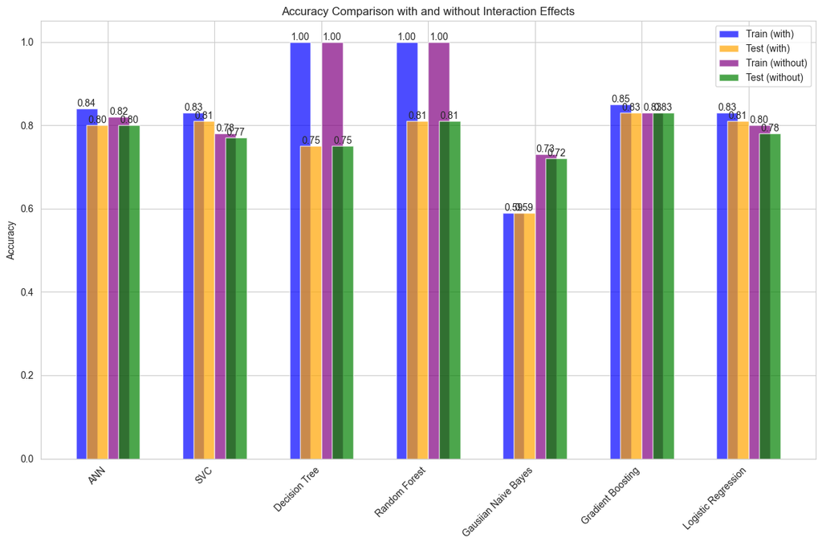

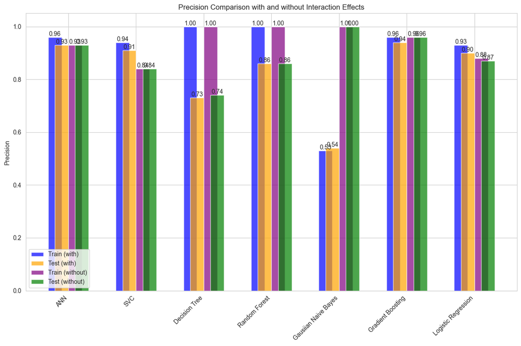

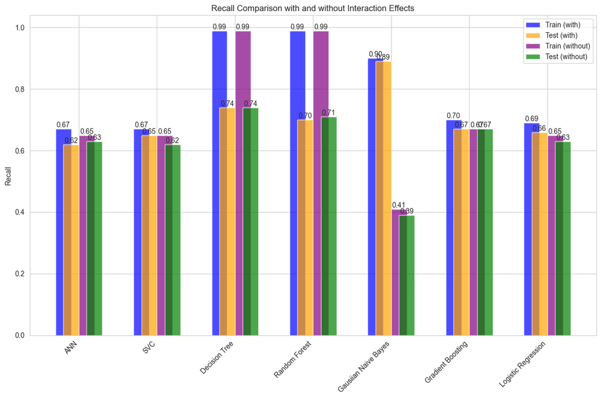

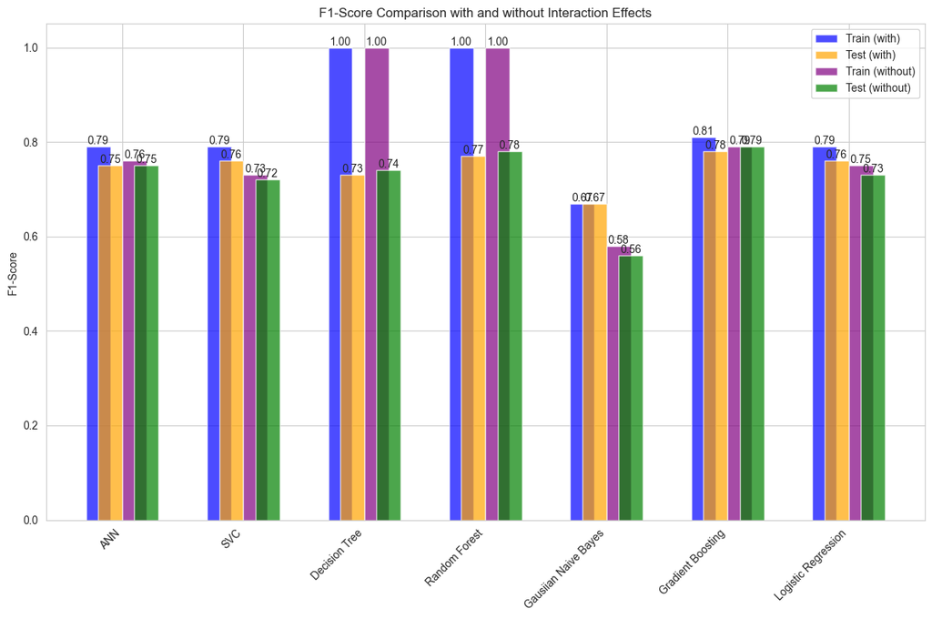

```python
import numpy as np
import matplotlib.pyplot as plt

# Define the model names and corresponding evaluation metrics
models = ['ANN', 'SVC', 'Decision Tree', 'Random Forest', 'Gausiian Naive Bayes', 'Gradient Boosting', 'Logistic Regression']
metrics = ['Accuracy', 'Precision', 'Recall', 'F1-Score']

# Evaluation metrics for models with interaction effects
train_metrics_with = np.array([
    [0.84, 0.83, 1.00, 1.00, 0.59, 0.85, 0.83],
    [0.96, 0.94, 1.00, 1.00, 0.53, 0.96, 0.93],
    [0.67, 0.67, 0.99, 0.99, 0.90, 0.70, 0.69],
    [0.79, 0.79, 1.00, 1.00, 0.67, 0.81, 0.79]
])

test_metrics_with = np.array([
    [0.80, 0.81, 0.75, 0.81, 0.59, 0.83, 0.81],
    [0.93, 0.91, 0.73, 0.86, 0.54, 0.94, 0.90],
    [0.62, 0.65, 0.74, 0.70, 0.89, 0.67, 0.66],
    [0.75, 0.76, 0.73, 0.77, 0.67, 0.78, 0.76]
])

# Evaluation metrics for models without interaction effects
train_metrics_without = np.array([
    [0.82, 0.78, 1.00, 1.00, 0.73, 0.83, 0.80],
    [0.93, 0.84, 1.00, 1.00, 1.00, 0.96, 0.88],
    [0.65, 0.65, 0.99, 0.99, 0.41, 0.67, 0.65],
    [0.76, 0.73, 1.00, 1.00, 0.58, 0.79, 0.75]
])

test_metrics_without = np.array([
    [0.80, 0.77, 0.75, 0.81, 0.72, 0.83, 0.78],
    [0.93, 0.84, 0.74, 0.86, 1.00, 0.96, 0.87],
    [0.63, 0.62, 0.74, 0.71, 0.39, 0.67, 0.63],
    [0.75, 0.72, 0.74, 0.78, 0.56, 0.79, 0.73]
])

# Function to create grouped bar plots for each metric
def create_grouped_bar_plot(metric_index, train_metrics_with, test_metrics_with, train_metrics_without, test_metrics_without):
    plt.figure(figsize=(12, 8))
    bar_width = 0.2
    bar_positions = np.arange(len(models))

    plt.bar(bar_positions - bar_width, train_metrics_with[metric_index], bar_width, label='Train (with)', color='blue', alpha=0.7)
    plt.bar(bar_positions - bar_width/2, test_metrics_with[metric_index], bar_width, label='Test (with)', color='orange', alpha=0.7)

    plt.bar(bar_positions + bar_width/2, train_metrics_without[metric_index], bar_width, label='Train (without)', color='purple', alpha=0.7)
    plt.bar(bar_positions + bar_width, test_metrics_without[metric_index], bar_width, label='Test (without)', color='green', alpha=0.7)

    plt.xticks(bar_positions, models, rotation=45, ha='right')
    plt.ylabel(metrics[metric_index])
    plt.title(f'{metrics[metric_index]} Comparison with and without Interaction Effects')
    plt.legend()

    # Add labels for each bar
    for i in range(len(models)):
        plt.text(bar_positions[i] - bar_width, train_metrics_with[metric_index, i], f"{train_metrics_with[metric_index, i]:.2f}", ha='center', va='bottom')
        plt.text(bar_positions[i] - bar_width/2, test_metrics_with[metric_index, i], f"{test_metrics_with[metric_index, i]:.2f}", ha='center', va='bottom')
        plt.text(bar_positions[i] + bar_width/2, train_metrics_without[metric_index, i], f"{train_metrics_without[metric_index, i]:.2f}", ha='center', va='bottom')
        plt.text(bar_positions[i] + bar_width, test_metrics_without[metric_index, i], f"{test_metrics_without[metric_index, i]:.2f}", ha='center', va='bottom')

    plt.tight_layout()
    plt.show()

# Create grouped bar plots for each metric
for i, metric in enumerate(metrics):
    create_grouped_bar_plot(i, train_metrics_with, test_metrics_with, train_metrics_without, test_metrics_without)
```

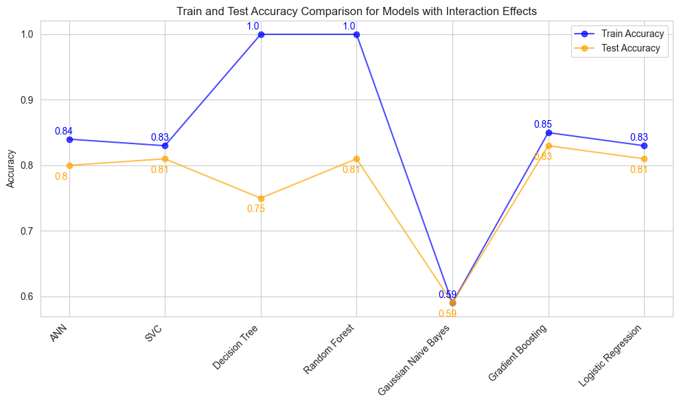

```python
import numpy as np
import matplotlib.pyplot as plt

# Define the model names and corresponding evaluation metrics
models = ['ANN', 'SVC', 'Decision Tree', 'Random Forest', 'Gaussian Naive Bayes', 'Gradient Boosting', 'Logistic Regression']
metrics = ['Accuracy']

# Evaluation metrics for models with interaction effects
train_accuracy_with = [0.84, 0.83, 1.00, 1.00, 0.59, 0.85, 0.83]
test_accuracy_with = [0.80, 0.81, 0.75, 0.81, 0.59, 0.83, 0.81]

# Create Line Plot for Accuracy comparison
plt.figure(figsize=(10, 6))
plt.plot(models, train_accuracy_with, marker='o', label='Train Accuracy', color='blue', alpha=0.7)
plt.plot(models, test_accuracy_with, marker='o', label='Test Accuracy', color='orange', alpha=0.7)

plt.xticks(rotation=45, ha='right')
plt.ylabel('Accuracy')
plt.title('Train and Test Accuracy Comparison for Models with Interaction Effects')
plt.legend()
plt.tight_layout()

# Adding labels to the data points on the plot
for i, j in zip(models, train_accuracy_with):
    plt.annotate(str(j), xy=(i, j), xytext=(-15, 5), textcoords='offset points', color='blue')

for i, j in zip(models, test_accuracy_with):
    plt.annotate(str(j), xy=(i, j), xytext=(-15, -15), textcoords='offset points', color='orange')

plt.grid(True)
plt.show()
```

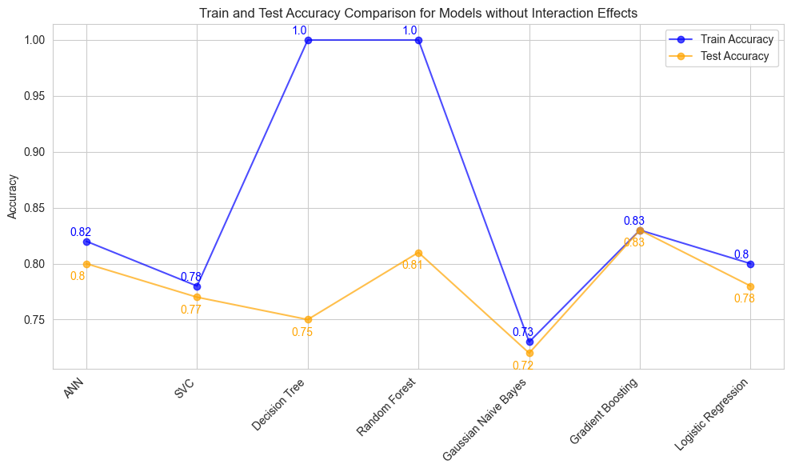

```python
import numpy as np
import matplotlib.pyplot as plt

# Define the model names and corresponding evaluation metrics
models = ['ANN', 'SVC', 'Decision Tree', 'Random Forest', 'Gaussian Naive Bayes', 'Gradient Boosting', 'Logistic Regression']
metrics = ['Accuracy']

# Evaluation metrics for models without interaction effects
train_accuracy_without = [0.82, 0.78, 1.00, 1.00, 0.73, 0.83, 0.80]
test_accuracy_without = [0.80, 0.77, 0.75, 0.81, 0.72, 0.83, 0.78]

# Create Line Plot for Accuracy comparison
plt.figure(figsize=(10, 6))
plt.plot(models, train_accuracy_without, marker='o', label='Train Accuracy', color='blue', alpha=0.7)
plt.plot(models, test_accuracy_without, marker='o', label='Test Accuracy', color='orange', alpha=0.7)

plt.xticks(rotation=45, ha='right')
plt.ylabel('Accuracy')
plt.title('Train and Test Accuracy Comparison for Models without Interaction Effects')
plt.legend()
plt.tight_layout()

# Adding labels to the data points on the plot
for i, j in zip(models, train_accuracy_without):
    plt.annotate(str(j), xy=(i, j), xytext=(-15, 5), textcoords='offset points', color='blue')

for i, j in zip(models, test_accuracy_without):
    plt.annotate(str(j), xy=(i, j), xytext=(-15, -15), textcoords='offset points', color='orange')

plt.grid(True)
plt.show()
```